# ComputingNotes.Rmd

# Preprocessing

- see script in APM package. Note that small error using lubridate::day() - with version 1.3.3 day() defaults to mday(), where authors intended the result from yday()

```r
head(fullSet)
```

```
## [1] "NumCI"  "NumDR"  "NumECI" "NumEA"  "NumHV"  "NumPS"
```

# Modelling

```r
library("caret")
library("earth")
library("kernlab")
library("klaR")
library("MASS")
library("mda")
library("nnet")
library("rrcov")
library("doMC")

registerDoMC(4)
```

```r
ctrl <- trainControl(method = "LGOGV",
                     summaryFunction = twoClassSummary,
                     classProbs = TRUE,
                     index = list(TrainSet = pre2008),
                     savePredictions = TRUE)
```

## Nonlinear Discriminant Analysis

A number of packages are available. QDA is implemented in the qda() functon in MASS as well as an outlier resistent version in QdaCov() in rrcov(). RDA is available in the rda() function in the klaR package, and MDA can be found in the mda package. The syntax is very similar

The mda function jas a model interface. The tuning parameter is the number of sbclasses per class, which do not have to be the same for each class

```r
mdaModel <- mda(Class ~ .,
                ## Reduce data to the relevant predictors and the
                ## class variable to use the formula shortcut
                data = training[pre2008, c("Class", reducedSet)],
                subclasses = 3)

mdaModel
```

```
## Call:
## mda(formula = Class ~ ., data = training[pre2008, c("Class",
##     reducedSet)], subclasses = 3)
##
## Dimension: 5
##
## Percent Between-Group Variance Explained:
##     v1     v2     v3     v4     v5
##  72.50  92.57  96.10  98.66 100.00
##
## Degrees of Freedom (per dimension): 253
##
## Training Misclassification Error: 0.18709 ( N = 6633 )
##
## Deviance: 6429.499
```

```r
predict(mdaModel, newdata = head(training[-pre2008, reducedSet]))
```

```
## [1] successful successful successful successful successful successful
## Levels: successful unsuccessful
```

Each of these nonlinear discriminant models can be built and optimal tuning parameters can be found using caret

```r
set.seed(476)
mdaFit <- train(training[, reducedSet],
                training$Class,
                method = "mda",
                metric = "ROC",
                preProc = c("center", "scale"),
                tuneGrid = expand.grid(subclasses = 1:7),
                trControl = ctrl)

mdaFit
```

```
## Mixture Discriminant Analysis
##
## 8190 samples
##  252 predictors
##    2 classes: 'successful', 'unsuccessful'
##
## Pre-processing: centered, scaled
## Resampling:
##
## Summary of sample sizes: 6633
##
## Resampling results across tuning parameters:
##
##   subclasses  ROC        Sens       Spec
##   1           0.8874473  0.8105263  0.8216819
##   2           0.8556231  0.7859649  0.8074975
##   3           0.8395243  0.7842105  0.8074975
##   4           0.8673990  0.7508772  0.8480243
##   5           0.8144795  0.7736842  0.7912867
##   6           0.8399598  0.7315789  0.8399189
##   7           0.8325859  0.7631579  0.8186424
##
## ROC was used to select the optimal model using  the largest value.
## The final value used for the model was subclasses = 1.
```

similar syntax can be used for RDS (method = RDA) and QDA (method values rda or QdaCov for the outlier-resistent versions in the rrcov package)

A penalised version of MDA is available in the sparseLDA package with the smda function.

## Neural networks

Focus here on the nnet package. The syntax is similar to regression, with a few exceptions. The linout argument should be set to FALSE since most classification models use a sigmoindal transformation to relate the hidden units to the outputs. The sums of squared errors or entropy estimates model parameters and the logical aarguments softmax and entropy toggle between the two

The package has both a formula interface and an interface for passing matrices or data frames for the predictors and the outcome. For the latter, the binary outcome cannot be a factor variable and must be converted to a set of C binary indicators. The package contais a function, class.ind, that is useful in making this conversion.

```r
head(class.ind(training$Class))
```

```
##      successful unsuccessful
## [1,]          1            0
## [2,]          1            0
## [3,]          1            0
## [4,]          1            0
## [5,]          0            1
## [6,]          1            0
```

Fit with the formula interface

```r
set.seed(800)
nnetModel <- nnet(Class ~ NumCI + CI.1960,
                  data = training[pre2008, ],
                  size = 3,
                  decay = 1)
nnetModel
```

```
## a 2-3-1 network with 13 weights
## inputs: NumCI CI.1960
## output(s): Class
## options were - entropy fitting  decay=1
```

```r
predict(nnetModel, newdata = head(testing))
```

```
##           [,1]
## 6641 0.5072662
## 6647 0.5072662
## 6649 0.5030059
## 6650 0.5663578
## 6655 0.5003263
## 6659 0.5331280
```

```r
predict(nnetModel, newdata = head(testing, type = "class"))
```

```
##           [,1]
## 6641 0.5072662
## 6647 0.5072662
## 6649 0.5030059
## 6650 0.5663578
## 6655 0.5003263
## 6659 0.5331280
```

When three or more classes are modelled, the basic call to predict produces columns for each class.

As before, train() provides a wrapper to this function. The same model code is used (method = “nnet”), and either the model interface is available, although train does allow factor variables in the classes (class.ind internally encodes to dummy variables). Also, as in regression, averaging can be done with stand-alone avNet or using train with method = “avNNet”.

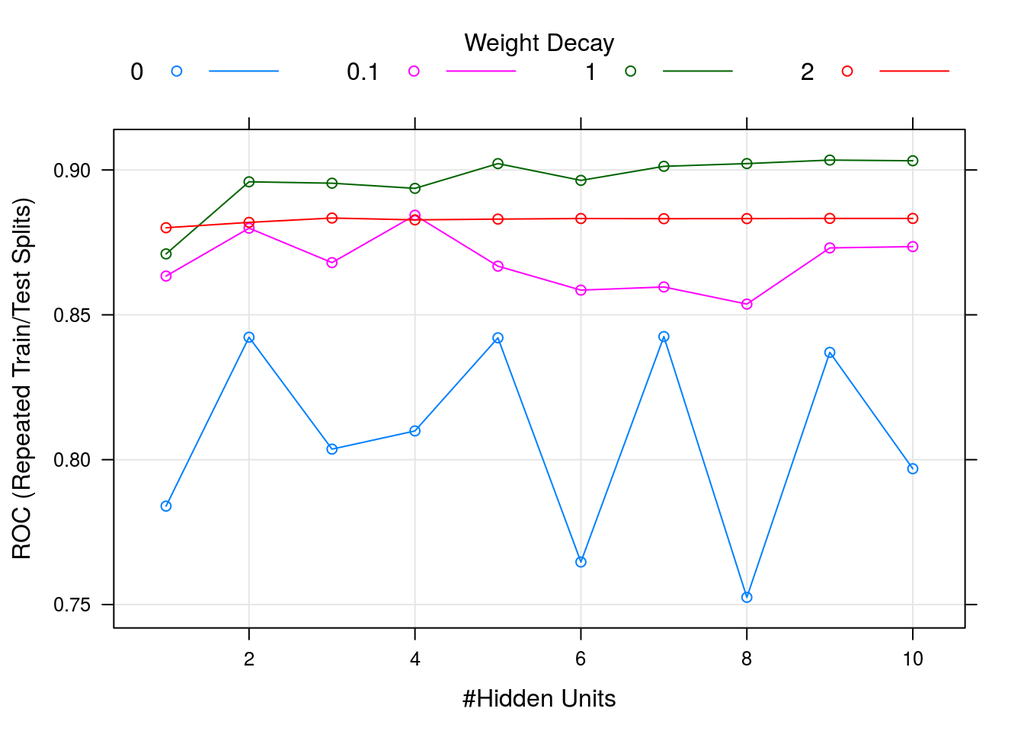

```r
ctrl <- trainControl(method = "LGOCV",
                     summaryFunction = twoClassSummary,
                     classProbs = TRUE,
                     index = list(TrainSet = pre2008),
                     savePredictions = TRUE)

nnetGrid <- expand.grid(size = 1:10, decay = c(0, .1, 1, 2))
maxSize <- max(nnetGrid$size)
set.seed(476)
nnetTune <- train(x = training[,reducedSet],
                  y = training$Class,
                  method = "nnet",
                  metric = "ROC",
                  preProc = c("center", "scale", "spatialSign"),
                  tuneGrid = nnetGrid,
                  trace = FALSE,
                  maxit = 2000,
                  MaxNWts = 1*(maxSize * (length(reducedSet) + 1) + maxSize + 1),
                  trControl = ctrl)
plot(nnetTune)
```

## Flexible discriminant analysis

The mda function has a function fda() for building this model. The model accepts the formula interface and has an option (method) that specifies the exact method for estimating the regression parameters. To use FDA with MARS, there are two approchs: method = mars uses the MARS implementation in the mda package. However, the earth package fits the MARS model with a wider range of options.

```r
library(earth)
fdaModel <- fda(Class ~ Day + NumCI,
                data = training[pre2008, ],
                method = earth)
```

Arguments to the earth function, such as nprune, can be specified when calling fda and are passed through earth. The MARS model is contained in a sub object called fit

```r
summary(fdaModel$fit)
```

```
## Call: earth(x=x, y=Theta, weights=weights)
##
##             coefficients
## (Intercept)    4.0181215
## h(Day-43)     -0.0233954
## h(Day-204)     0.0325841
## h(228-Day)    -0.0220304
## h(Day-228)    -0.0194733
## h(Day-319)     0.1575600
## h(Day-328)    -1.7443902
## h(Day-329)     2.1335169
## h(Day-331)    -1.6674195
## h(Day-332)     1.3722089
## h(Day-336)    -0.2929298
##
## Selected 11 of 12 terms, and 1 of 2 predictors
## Termination condition: Reached nk 21
## Importance: Day, NumCI-unused
## Number of terms at each degree of interaction: 1 10 (additive model)
## GCV 0.8548567    RSS 5634.417    GRSq 0.1454011    RSq 0.1505477
```

Note the final model coefficients have not been post-processed. The final model coefficients can be found with coef(fdaModel). To predict

```r
predict(fdaModel, head(training[-pre2008, ]))
```

```
## [1] successful successful successful successful successful successful
## Levels: successful unsuccessful
```

With train()

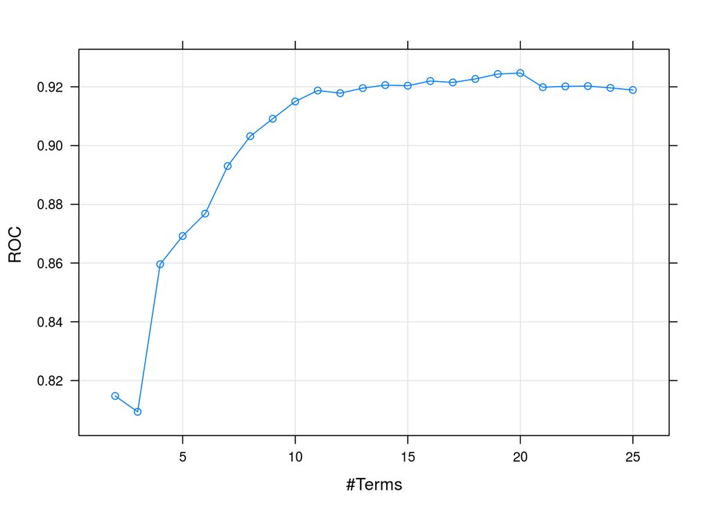

```r
set.seed(476)
fdaGrid <- expand.grid(nprune = 2:25,
                       degree = 1)
fdaTune <- train(x = training[, reducedSet],
                 y = training$Class,
                 method = "fda",
                 metric = "ROC",
                 tuneGrid =fdaGrid,
                 trace = FALSE,
                 trControl = ctrl)

plot(fdaTune)
```

## Support Vector Machines

The kernlab is the most comprehensive package for SVM’s. The syntax for SVM classifiers is largely the same a sthe regression case. Although the epsilon parameter is only relevent for regression, a few other parameters are useful in classification:

- the logical prob.model argument triggers ksvm to estiate an additional set of parameters for a sigmoindal function to translate the SVM decision values to class probabilities. If this method is not set to true, class probabilities cannot be predicted.
- The class.weights argument assigns assymetric costs to each class. This can be important where one or more specific types of errors are more harmful than others or when there is a severe class imbalance that biases the model to the majoruty class (will be discussed later chapters). The sytax here is to use a namesd vector of weights or costs. For example, if there was a desire to bias the grant model to detect unuccessful grants, the syntax would be class.weights = c(successful = 1, unsuccessful = 5) This would make a false negative five times more costly than a false positive. Note that the implementation of class weights in ksvm affects the predicted class, but the class probability model is uneffected by weights (in this implementation) This will be discussed in C17.

To fit a radial basis function on reduced set of predictors:

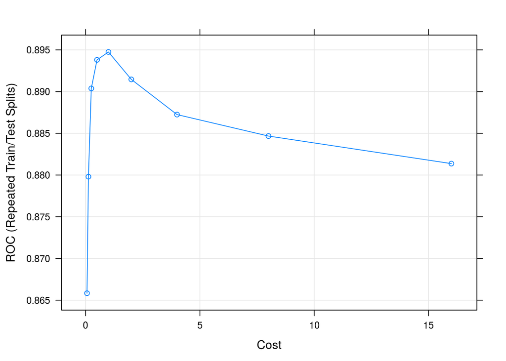

```r
set.seed(202)
# estimate sigma
sigmaRangeReduced <- sigest(as.matrix(training[, reducedSet]))
svmRGridReduced <- expand.grid(sigma = sigmaRangeReduced[1],
                               C = 2 ^ (seq(-4, 4)))
set.seed(476)
svmRTune <- train(training[, reducedSet],
                  training$Class,
                  method = "svmRadial",
                  metric = "ROC",
                  preProc = c("center", "scale"),
                  tuneGrid = svmRGridReduced,
                  fit = FALSE,
                  trControl = ctrl)

plot(svmRTune)
```

When the outcome is a factor, the function automatically used prob.model = TRUE

Other kernel functions can be defined using the kernel and kpar arguments, or use the train() method = “”

To predict:

```r
head(predict(svmRTune, newdata = head(training[-pre2008, reducedSet])))
```

```
## [1] successful   successful   successful   successful   unsuccessful
## [6] successful
## Levels: successful unsuccessful
```

```r
head(predict(svmRTune, newdata = head(training[-pre2008, reducedSet]), type = "prob"))
```

```
##   successful unsuccessful
## 1  0.9499102   0.05008983
## 2  0.8473771   0.15262290
## 3  0.8466158   0.15338425
## 4  0.9445195   0.05548049
## 5  0.4290893   0.57091073
## 6  0.9519568   0.04804321
```

## K Nearest Neighbors

Very similar syntax to the regression version

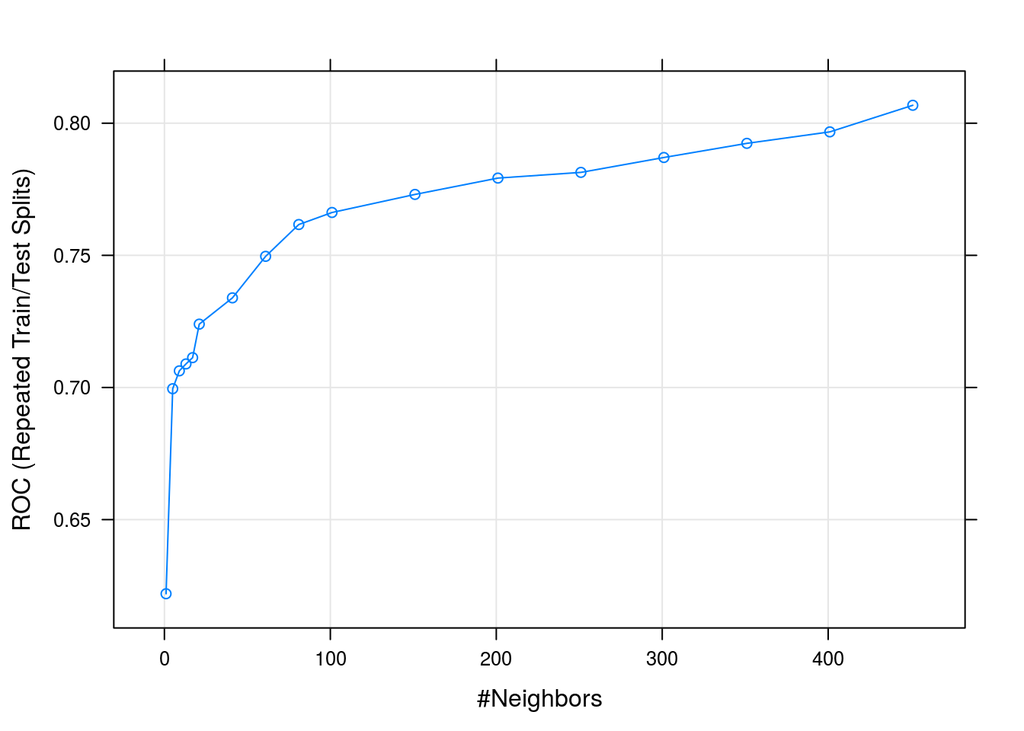

```r
set.seed(476)
knnFit <- train(training[, reducedSet],
                training$Class,
                method = "knn",
                metric = "ROC",
                preProc = c("center", "scale"),
                tuneGrid = data.frame(k = c(4 * (0:5) + 1,
                                            20 * (1:5) + 1,
                                            50 * (2:9) + 1)),
                trControl = ctrl)
plot(knnFit)
```

```r
library("pROC")
```

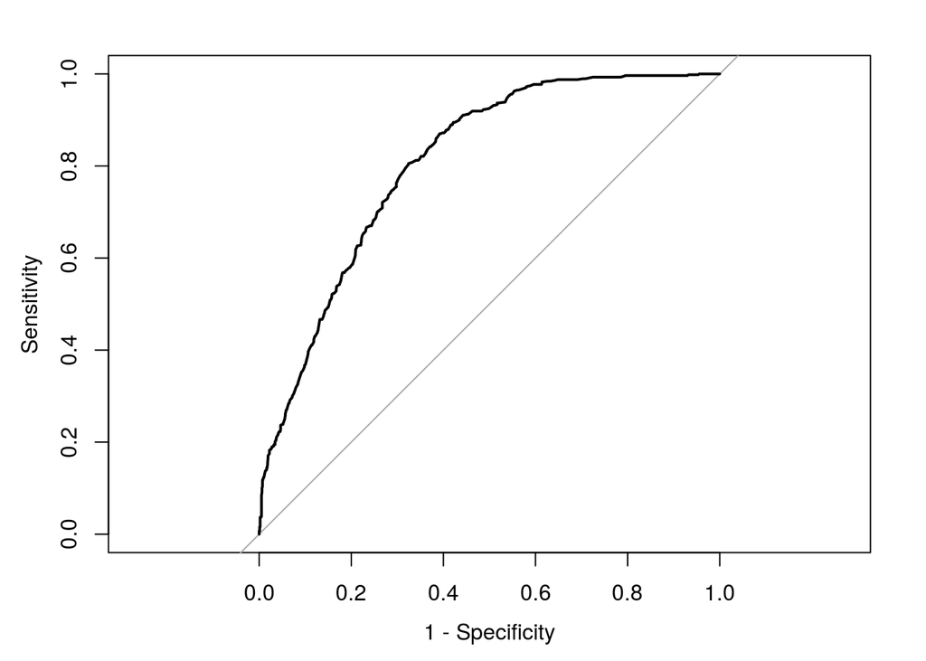

```
##
## Call:
## roc.default(response = knnFit$pred$obs, predictor = knnFit$pred$successful,     levels = rev(levels(knnFit$pred$obs)))
##
## Data: knnFit$pred$successful in 987 controls (knnFit$pred$obs unsuccessful) < 570 cases (knnFit$pred$obs successful).
## Area under the curve: 0.8068
```

```r
knnFit$pred <- merge(knnFit$pred, knnFit$bestTune)
knnRoc <- roc(response = knnFit$pred$obs,
              predictor = knnFit$pred$successful,
              levels = rev(levels(knnFit$pred$obs)))
plot(knnRoc, legacy.axes = TRUE)
```

## Naive Bayes

The two main functions for fitting the naive Bayes models in R are naiveBayes() in e1071 package, NaiveBayes() in the klaR package. Both offer Laplace corrections, but the bersion in the KlaR package has the option of using conditional density estimates that are more flexible.

Both functions accept the formula and non-formula approaches to specifying the model terms. However, feeding these models binary dummy variables instead of factor variables is problematic as individual categpries will be treates as numerical data and the model will estimate the probability density function from a continuous dirstribution, such as Gaussian.

To follow the strategy described above where many of the predictors are converted to factor variables, we create alternate versions fo the traninng and test sets:

```r
# NO IDEA WHAT GOING WRONG HERE

# some predictors already stored as factors
factors <- c("SponsorCode", "ContractValueBand", "Month", "Weekday")
nbPredictors <- factorPredictors[factorPredictors %in% reducedSet]
nbPredictors <- c(nbPredictors, factors)
nbPredictors <- nbPredictors[nbPredictors != "SponsorUnk"]

nbTraining <- training[, c("Class", nbPredictors)]
nbTesting <- testing[, c("Class", nbPredictors)]


nbTraining$Class <- training$Class
nbTesting$Class <- testing$Class

training[, nbPredictors[[1]]]

# loop thorough predictors and convert some to factors
for(i in nbPredictors)
{
  if(length(unique(training[,i])) <= 15)
  {
    nbTraining[, i] <- factor(nbTraining[,i], levels = paste(sort(unique(training[,i]))))
    nbTesting[, i] <- factor(nbTesting[,i], levels = paste(sort(unique(training[,i]))))
  }
}
```

Now we can use Naive Bayes:

```r
nBayesFit <- NaiveBayes(Class ~ .,
                        data = nbTraining[pre2008, ],
                        # should the non-parametric kernel be used?
                        usekernel = TRUE,
                        # laplace coreectiob value
                        fL = 2)
```

To train Naive Bayes, tune iver the density estimate method and the Laplace correction. By default, the function evaluates probabilities with normal distribution and the nonparametric method (and no Laplace correction)